# 1 - Mean total number of steps taken per day

```r
library("utils")
library("plyr")
library("xtable")
library("lattice")
```

Download and read the data into a dataframe.

```r
work.file.name <- "activity.csv"
zip.file.name <- "Factivity.zip"

if (!(file.exists(work.file.name))) {
    download.file("https://d396qusza40orc.cloudfront.net/repdata/data/Factivity.zip",
                  destfile = zip.file.name, method = "curl")
    unzip(zip.file.name)
}

original.df <- read.csv(work.file.name)
```

### 1 - Mean total number of steps taken per day

Using the original dataframe, create a new dataframe (summary.df), that summarizes the steps based on the day. Note that observations that have no (NA) steps are excluded.

```r
summary.df <- ddply(original.df[!(is.na(original.df$steps)), ],
                    .(date),
                    summarise,
                    Mean = round(mean(steps), 2),
                    Median = median(steps),
                    Sum = sum(steps))
```

- Plot a histogram of the total number of steps taken each day

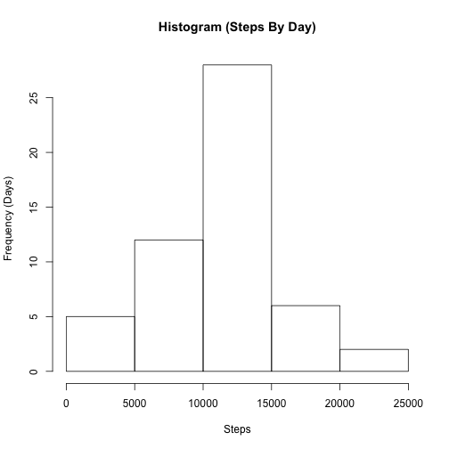

```r
hist(summary.df$Sum,
        main = "Histogram (Steps By Day)",
        xlab = "Steps",
        ylab = "Frequency (Days)")
```

- Display a table showing the mean and median of the total number of steps taken per day

```r
print(xtable(summary.df), type = "html")
```

|  | date | Mean | Median | Sum |
| --- | --- | --- | --- | --- |
| 1 | 2012-10-02 | 0.44 | 0.00 | 126 |
| 2 | 2012-10-03 | 39.42 | 0.00 | 11352 |
| 3 | 2012-10-04 | 42.07 | 0.00 | 12116 |
| 4 | 2012-10-05 | 46.16 | 0.00 | 13294 |
| 5 | 2012-10-06 | 53.54 | 0.00 | 15420 |
| 6 | 2012-10-07 | 38.25 | 0.00 | 11015 |
| 7 | 2012-10-09 | 44.48 | 0.00 | 12811 |
| 8 | 2012-10-10 | 34.38 | 0.00 | 9900 |
| 9 | 2012-10-11 | 35.78 | 0.00 | 10304 |
| 10 | 2012-10-12 | 60.35 | 0.00 | 17382 |
| 11 | 2012-10-13 | 43.15 | 0.00 | 12426 |
| 12 | 2012-10-14 | 52.42 | 0.00 | 15098 |
| 13 | 2012-10-15 | 35.20 | 0.00 | 10139 |
| 14 | 2012-10-16 | 52.38 | 0.00 | 15084 |
| 15 | 2012-10-17 | 46.71 | 0.00 | 13452 |
| 16 | 2012-10-18 | 34.92 | 0.00 | 10056 |
| 17 | 2012-10-19 | 41.07 | 0.00 | 11829 |
| 18 | 2012-10-20 | 36.09 | 0.00 | 10395 |
| 19 | 2012-10-21 | 30.63 | 0.00 | 8821 |
| 20 | 2012-10-22 | 46.74 | 0.00 | 13460 |
| 21 | 2012-10-23 | 30.97 | 0.00 | 8918 |
| 22 | 2012-10-24 | 29.01 | 0.00 | 8355 |
| 23 | 2012-10-25 | 8.65 | 0.00 | 2492 |
| 24 | 2012-10-26 | 23.53 | 0.00 | 6778 |
| 25 | 2012-10-27 | 35.14 | 0.00 | 10119 |
| 26 | 2012-10-28 | 39.78 | 0.00 | 11458 |
| 27 | 2012-10-29 | 17.42 | 0.00 | 5018 |
| 28 | 2012-10-30 | 34.09 | 0.00 | 9819 |
| 29 | 2012-10-31 | 53.52 | 0.00 | 15414 |
| 30 | 2012-11-02 | 36.81 | 0.00 | 10600 |
| 31 | 2012-11-03 | 36.70 | 0.00 | 10571 |
| 32 | 2012-11-05 | 36.25 | 0.00 | 10439 |
| 33 | 2012-11-06 | 28.94 | 0.00 | 8334 |
| 34 | 2012-11-07 | 44.73 | 0.00 | 12883 |
| 35 | 2012-11-08 | 11.18 | 0.00 | 3219 |
| 36 | 2012-11-11 | 43.78 | 0.00 | 12608 |
| 37 | 2012-11-12 | 37.38 | 0.00 | 10765 |
| 38 | 2012-11-13 | 25.47 | 0.00 | 7336 |
| 39 | 2012-11-15 | 0.14 | 0.00 | 41 |
| 40 | 2012-11-16 | 18.89 | 0.00 | 5441 |
| 41 | 2012-11-17 | 49.79 | 0.00 | 14339 |
| 42 | 2012-11-18 | 52.47 | 0.00 | 15110 |
| 43 | 2012-11-19 | 30.70 | 0.00 | 8841 |
| 44 | 2012-11-20 | 15.53 | 0.00 | 4472 |
| 45 | 2012-11-21 | 44.40 | 0.00 | 12787 |
| 46 | 2012-11-22 | 70.93 | 0.00 | 20427 |
| 47 | 2012-11-23 | 73.59 | 0.00 | 21194 |
| 48 | 2012-11-24 | 50.27 | 0.00 | 14478 |
| 49 | 2012-11-25 | 41.09 | 0.00 | 11834 |
| 50 | 2012-11-26 | 38.76 | 0.00 | 11162 |
| 51 | 2012-11-27 | 47.38 | 0.00 | 13646 |
| 52 | 2012-11-28 | 35.36 | 0.00 | 10183 |
| 53 | 2012-11-29 | 24.47 | 0.00 | 7047 |

### 2 - The average daily activity pattern

```r
avg.steps.by.interval.df <- ddply(original.df[!(is.na(original.df$steps)), ],
                                .(interval),
                                summarise,
                                Steps = round(mean(steps), 2))
```

- Make a time series plot of the 5-minute interval (x-axis) and the average number of steps taken, averaged across all days (y-axis)

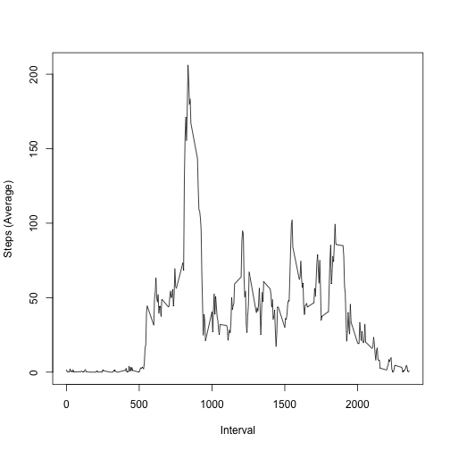

```r
plot(avg.steps.by.interval.df$interval,
     avg.steps.by.interval.df$Steps,
     xlab="Interval",
     ylab="Steps (Average)",
     type="l")
```

- Determine the 5-minute interval that, on average, contains the maximum number of steps

```r
max.steps.interval <- avg.steps.by.interval.df[avg.steps.by.interval.df$Steps == max(avg.steps.by.interval.df$Steps), ]
```

#### The 5-minute interval that, on average, contains the maximum number of steps is 835.

### 3 - Imputing missing values

- Calculate the mean of all the steps that were provided. The mean will be used to back-fill those observations for which steps were not provided. Calulate and store the mean value to mean.of.non.na.steps

```r
mean.of.non.na.steps <- as.integer(mean(original.df$steps[!is.na(original.df$steps)]))
```

- Create a new dataset that is equal to the original dataset but with the missing data filled in. Using the calculated mean value replace hte missing values and create a new dataset called original.backfill.df.

```r
original.backfill.df <- original.df
original.backfill.df$steps <- replace(original.backfill.df$steps, is.na(original.backfill.df$steps), mean.of.non.na.steps)
```

- Using the original.backfill.df dataset, create a new dataset (summary.backfill.df), that summarizes the steps based on the day, after th missing data has been inputted.

```r
summary.backfill.df <- ddply(original.backfill.df,
                            .(date),
                            summarise,
                            Mean = round(mean(steps), 2),
                            Median = median(steps),
                            Sum = sum(steps))
```

- Using the dataset original.backfill.df create a histogram of the total number of steps taken each day – after missing values were inputted

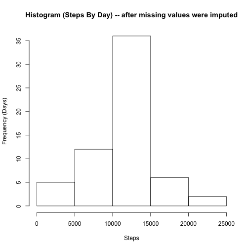

```r
hist(summary.backfill.df$Sum,
      main = "Histogram (Steps By Day) -- after missing values were imputed",
      xlab = "Steps",
      ylab = "Frequency (Days)")
```

- Display a table showing the mean and median of the total number of steps taken per day – after missing values were inputted

```r
print(xtable(summary.backfill.df), type = "html")
```

|  | date | Mean | Median | Sum |
| --- | --- | --- | --- | --- |
| 1 | 2012-10-01 | 37.00 | 37.00 | 10656 |
| 2 | 2012-10-02 | 0.44 | 0.00 | 126 |
| 3 | 2012-10-03 | 39.42 | 0.00 | 11352 |
| 4 | 2012-10-04 | 42.07 | 0.00 | 12116 |
| 5 | 2012-10-05 | 46.16 | 0.00 | 13294 |
| 6 | 2012-10-06 | 53.54 | 0.00 | 15420 |
| 7 | 2012-10-07 | 38.25 | 0.00 | 11015 |
| 8 | 2012-10-08 | 37.00 | 37.00 | 10656 |
| 9 | 2012-10-09 | 44.48 | 0.00 | 12811 |
| 10 | 2012-10-10 | 34.38 | 0.00 | 9900 |
| 11 | 2012-10-11 | 35.78 | 0.00 | 10304 |
| 12 | 2012-10-12 | 60.35 | 0.00 | 17382 |
| 13 | 2012-10-13 | 43.15 | 0.00 | 12426 |
| 14 | 2012-10-14 | 52.42 | 0.00 | 15098 |
| 15 | 2012-10-15 | 35.20 | 0.00 | 10139 |
| 16 | 2012-10-16 | 52.38 | 0.00 | 15084 |
| 17 | 2012-10-17 | 46.71 | 0.00 | 13452 |
| 18 | 2012-10-18 | 34.92 | 0.00 | 10056 |
| 19 | 2012-10-19 | 41.07 | 0.00 | 11829 |
| 20 | 2012-10-20 | 36.09 | 0.00 | 10395 |
| 21 | 2012-10-21 | 30.63 | 0.00 | 8821 |
| 22 | 2012-10-22 | 46.74 | 0.00 | 13460 |
| 23 | 2012-10-23 | 30.97 | 0.00 | 8918 |
| 24 | 2012-10-24 | 29.01 | 0.00 | 8355 |
| 25 | 2012-10-25 | 8.65 | 0.00 | 2492 |
| 26 | 2012-10-26 | 23.53 | 0.00 | 6778 |
| 27 | 2012-10-27 | 35.14 | 0.00 | 10119 |
| 28 | 2012-10-28 | 39.78 | 0.00 | 11458 |
| 29 | 2012-10-29 | 17.42 | 0.00 | 5018 |
| 30 | 2012-10-30 | 34.09 | 0.00 | 9819 |
| 31 | 2012-10-31 | 53.52 | 0.00 | 15414 |
| 32 | 2012-11-01 | 37.00 | 37.00 | 10656 |
| 33 | 2012-11-02 | 36.81 | 0.00 | 10600 |
| 34 | 2012-11-03 | 36.70 | 0.00 | 10571 |
| 35 | 2012-11-04 | 37.00 | 37.00 | 10656 |
| 36 | 2012-11-05 | 36.25 | 0.00 | 10439 |
| 37 | 2012-11-06 | 28.94 | 0.00 | 8334 |
| 38 | 2012-11-07 | 44.73 | 0.00 | 12883 |
| 39 | 2012-11-08 | 11.18 | 0.00 | 3219 |
| 40 | 2012-11-09 | 37.00 | 37.00 | 10656 |
| 41 | 2012-11-10 | 37.00 | 37.00 | 10656 |
| 42 | 2012-11-11 | 43.78 | 0.00 | 12608 |
| 43 | 2012-11-12 | 37.38 | 0.00 | 10765 |
| 44 | 2012-11-13 | 25.47 | 0.00 | 7336 |
| 45 | 2012-11-14 | 37.00 | 37.00 | 10656 |
| 46 | 2012-11-15 | 0.14 | 0.00 | 41 |
| 47 | 2012-11-16 | 18.89 | 0.00 | 5441 |
| 48 | 2012-11-17 | 49.79 | 0.00 | 14339 |
| 49 | 2012-11-18 | 52.47 | 0.00 | 15110 |
| 50 | 2012-11-19 | 30.70 | 0.00 | 8841 |
| 51 | 2012-11-20 | 15.53 | 0.00 | 4472 |
| 52 | 2012-11-21 | 44.40 | 0.00 | 12787 |
| 53 | 2012-11-22 | 70.93 | 0.00 | 20427 |
| 54 | 2012-11-23 | 73.59 | 0.00 | 21194 |
| 55 | 2012-11-24 | 50.27 | 0.00 | 14478 |
| 56 | 2012-11-25 | 41.09 | 0.00 | 11834 |
| 57 | 2012-11-26 | 38.76 | 0.00 | 11162 |
| 58 | 2012-11-27 | 47.38 | 0.00 | 13646 |
| 59 | 2012-11-28 | 35.36 | 0.00 | 10183 |
| 60 | 2012-11-29 | 24.47 | 0.00 | 7047 |
| 61 | 2012-11-30 | 37.00 | 37.00 | 10656 |

### 4 - Are there differences in activity patterns between weekdays and weekends?

- Create a new factor variable in the dataset with two levels – “weekday” and “weekend” indicating whether a given date is a weekday or weekend day.

```r
original.backfill.df$day.type <- ifelse(weekdays(as.Date(original.backfill.df$date)) %in% c("Saturday","Sunday"), "weekend", "weekday")
original.backfill.df$day.type <- as.factor(original.backfill.df$day.type)
```

```r
summary.weekday.df <- ddply(original.backfill.df[original.backfill.df$day.type == "weekday", ],
                          .(interval),
                          summarise,
                          Steps = round(mean(steps), 2),
                          day = "weekday")

summary.weekend.df <- ddply(original.backfill.df[original.backfill.df$day.type == "weekend", ],
                          .(interval),
                          summarise,
                          Steps = round(mean(steps), 2),
                          day = "weekend")


total.summary.df <- rbind(summary.weekend.df, summary.weekday.df)
```

- Make a panel plot containing a time series plot (i.e. type = “l”) of the 5-minute interval (x-axis) and the average number of steps taken, averaged across all weekday days or weekend days (y-axis)

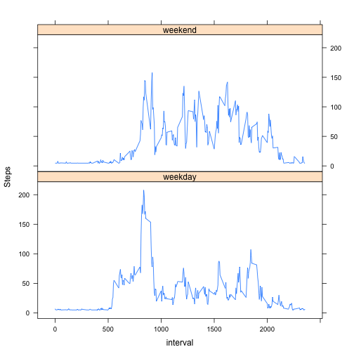

```r
xyplot(Steps ~ interval | factor(day), total.summary.df, plot.points = FALSE, type = "l", layout = c(1,2))
```